# TEAM-C

## 4 clusters (without MOnths, VisitorType, Weekend and Revenue columns(categorical))

```r
#divide online shoppers intention   into    four    clusters
intention_clusters6 <-  kmeans(intention_z2, 4)

# exploring the clusters - size, centroids
intention_clusters6$size
```

```
## [1] 2579  592  964 8195
```

```r
intention_clusters6$centers
```

```
##   Administrative Administrative_Duration Informational
## 1      1.1899530               0.9007098     0.3187978
## 2      1.4357625               1.0447007     2.7620659
## 3     -0.6860347              -0.4492647    -0.3882948
## 4     -0.3975013              -0.3060771    -0.2541802
##   Informational_Duration ProductRelated ProductRelated_Duration
## 1             0.03634425      0.4713030               0.3945826
## 2             2.91676657      2.3827637               2.3537072
## 3            -0.24466851     -0.6491786              -0.5971275
## 4            -0.19336146     -0.2440852              -0.2239649
##   BounceRates  ExitRates  PageValues  SpecialDay OperatingSystems
## 1  -0.3382955 -0.4991094  0.52309975 -0.18327465    -0.0241724760
## 2  -0.3153925 -0.4729778  0.08736718 -0.15255755    -0.0155917961
## 3   3.1593762  2.9183121 -0.31716498  0.23667533     0.0688179467
## 4  -0.2423993 -0.1520496 -0.13362399  0.04085715     0.0006382744
##       Browser      Region   TrafficType
## 1 -0.05034074  0.03066789 -0.0719072961
## 2 -0.07318424 -0.16756878 -0.1398275689
## 3 -0.01947564 -0.02896551  0.2703215518
## 4  0.02342018  0.00586101  0.0009318928
```

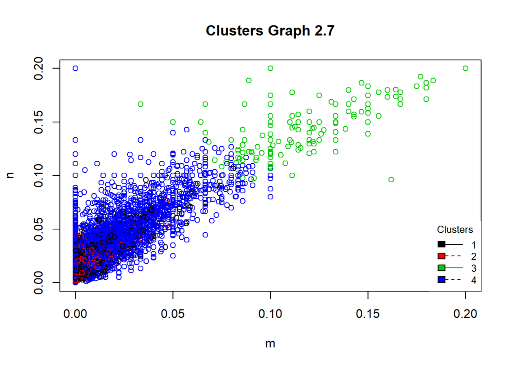

```r
#PLOT
funct_plot(online_intention$BounceRates, online_intention$ExitRates,
           intention_clusters6$cluster, 2.7) # graph 16
```

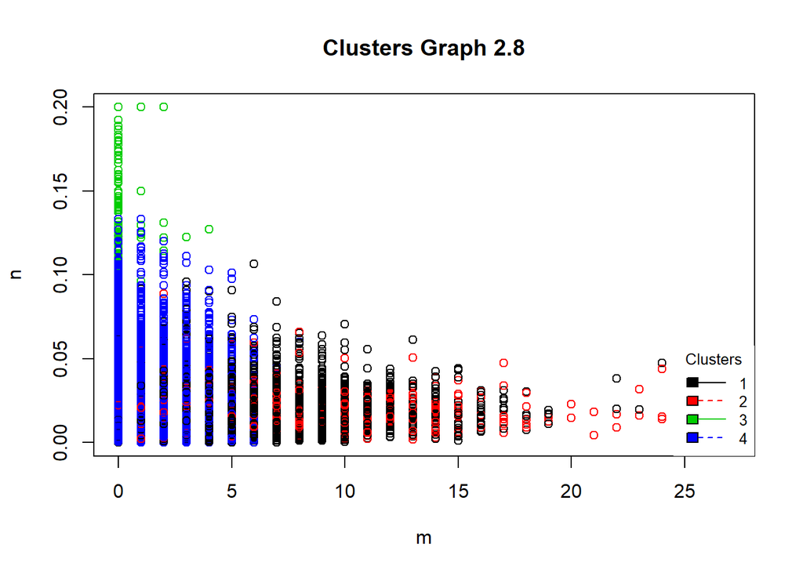

```r
funct_plot(online_intention$Administrative, online_intention$ExitRates,
           intention_clusters6$cluster, 2.8)# graph 17
```

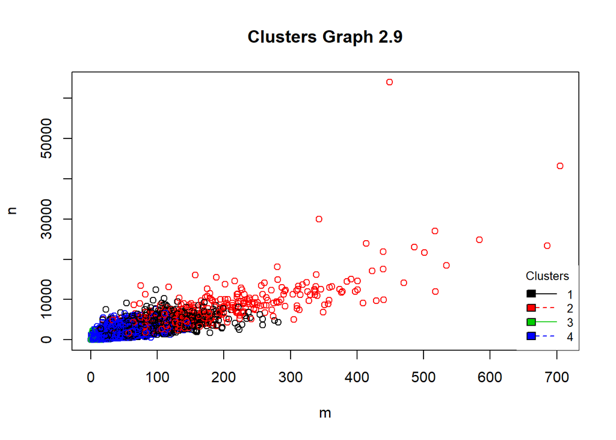

```r
funct_plot(online_intention$ProductRelated, online_intention$ProductRelated_Duration,
           intention_clusters6$cluster, 2.9)# graph 18
```

```r
#get the clusters means
aggregate(intention, by=list(intention_clusters6$cluster), FUN = mean)
```

```
##   Group.1 Administrative Administrative_Duration Informational
## 1       1     6.26793331              240.045281    0.90849166
## 2       2     7.08445946              265.499864    4.01182432
## 3       3     0.03630705                1.397994    0.01037344
## 4       4     0.99475290               26.710568    0.18071995
##   Informational_Duration ProductRelated ProductRelated_Duration
## 1            39.58782582      52.692904              1949.84677
## 2           445.00523448     137.706081              5698.96342
## 3             0.03547718       2.858921                52.04175
## 4             7.25690846      20.875656               766.15149
##   BounceRates  ExitRates PageValues SpecialDay    Month OperatingSystems
## 1 0.005787998 0.01881781  15.602402 0.02497092 8.183404         2.101978
## 2 0.006898530 0.02008771   7.511530 0.03108108 8.880068         2.109797
## 3 0.175384229 0.18489267   0.000000 0.10850622 6.849585         2.186722
## 4 0.010437846 0.03568371   3.408069 0.06955461 7.490421         2.124588
##    Browser   Region TrafficType Return_visitor New_visitor no_weekend
## 1 2.270648 3.221016    3.780147      0.8507173  0.14385421  0.7561070
## 2 2.231419 2.744932    3.506757      0.9645270  0.03378378  0.7246622
## 3 2.323651 3.077801    5.157676      0.9533195  0.03008299  0.8329876
## 4 2.397315 3.161440    4.073337      0.8379500  0.15546065  0.7663209
##   no_renevue
## 1  0.7119038
## 2  0.6993243
## 3  0.9948133
## 4  0.8801708
```

```r
#append cluster assignment
online_intention <- data.frame(online_intention, intention_clusters6$cluster)
```

comparison 2 clusters with all the variables there is not clear the two cluster in the graph 1.1, looks like Traditional Hierarchical Clustering, but using the others graphs look different patterns- againts in the graph 2.1 there is a Partitional Clustering. could be a reason for it, the categorical varaibles such as revenue is used by classification in which there is a two clusters. the first cluster analysis in general the clusters are mixed and not easy to identyfied. on the other hands, in the second analysis there are clear division among clusters.

NOTE. the graphs are in two dimension, maybe could be different the visualisation in three or more dimensions.

# REFLECTION

We broke down the tasks between the four of us with each member doing the code for one of the techniques. Tom did kNN, Lee did Decision Trees, Erik did K-means and Reenu did Regression. For the RMarkdown and reflection sections we split the work evenly and all added to these parts.

From use the use of the Decision trees we have gathered an informative insight into the usability of the various models. Decision trees are extremely fast at classifying unknown records and provide visualizations that can be easily interpreted by target audiences. Decision trees also allow for the accuracy to be comparable to other classification techniques which ensures that an analyst can find the most accurate results. Our use of decision trees delivered 100% accuracy in classifying mushrooms between poisonous and non-poisonous species.

K-means clustering is a method of cluster analysis which groups records into k clusters based on the nearest mean value of the cluster. It is a form unsupervised, no model. There is no definite value for the number of clusters, so it was determined by the elbow method. With k-means the initial centres for each cluster can be different each time that we used different columns as input in the algorithm, so the pattern of clustering will be different each type.

Regression is used to predict a continuous dependant variable from several independent variables. We decided to merge both wine quality datasets to build a model. During the implementation we discovered different libraries like regclass, leaps, physch and corrplot which helped give a better understanding of regression. Apart from the general analysis Iweliked using Anova with regression to find out the insignificant variable in the model which seems useful in terms of predicting the significance of the regression model.